# The effects of state redistricting policies on voter turnout, 2000-2020

Brian Holland, Brad Wayne, Kumar H, Grace Jensen, Chuyuan Zhong

2022-12-05

# Intro: Redistricting vs. Gerrymandering

- **Redistricting**:
- Part of the constitution, designed to ensure fair representation
- Based on results of decennial census
- All states with more than 1 district redraw their maps
- Traditionally done by state legislatures
- Generally speaking, vote share should be close to seat share
- **Gerrymandering**:
- Almost as old as the constitution itself
- Drawing districts in peculiar ways to gain political advantage
- Party in power can entrench itself to maintain power

# Gerrymandering Examples

[figure not shown]

Example Districts (40% Yellow Voters, 60% Blue Voters):

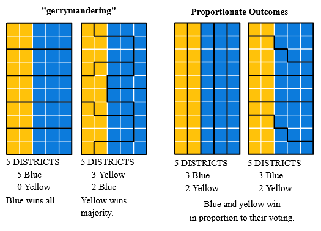

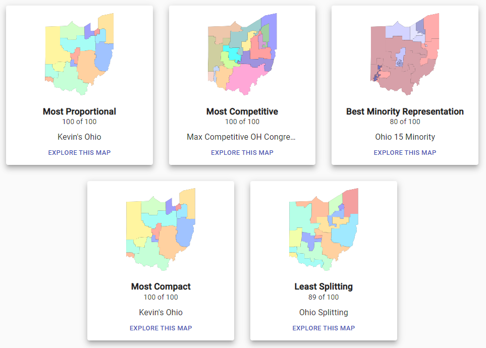

Best Ohio maps

(source: DavesRedistricting.org)

# Research questions

- **Is there a statistically significant relationship between the redistricting institution and turnout in Congressional elections? Specifically, do partisan methods lead to lower turnout?**
- **Do partisan redistricting methods lead to more lopsided races - larger vote margins?**

# Redistricting institutions: Types

- **Redistricting** - Redrawing of legislative district lines following the census in order to accommodate population shifts and keep districts as equal as possible.
- Each state has its own institution for drawing new congressional districts after a census:
- Legislature
- Commission (politican, independent, backup)
- Courts (Federal, State)
- Exceptions (single-district states)
- **Partisan** (State legislatures or politicians) or **non-partisan** (more independent 3rd parties)

# State-wise redistricting policies

- Legislative redistricting is the most common.

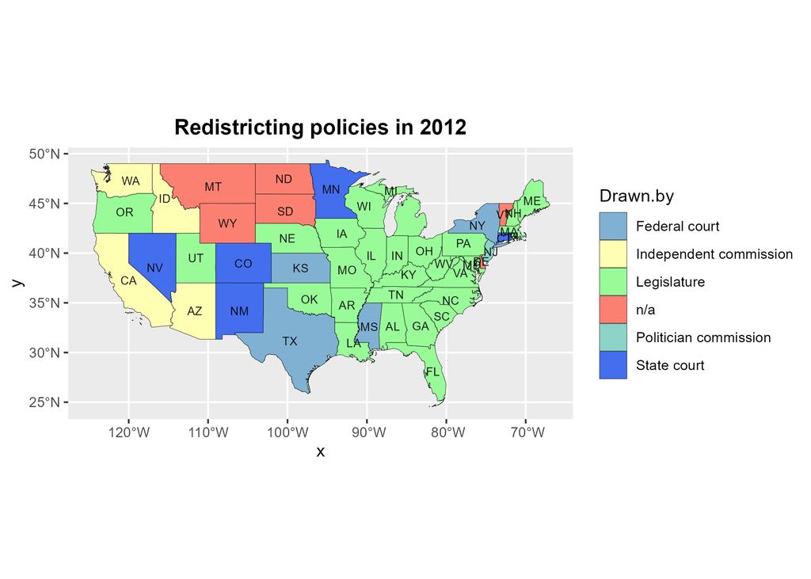

Fig. 1

# Background and Hypothesis

- **Prior research**:
  - Higher turnout for some groups when assigned to ethnic majority districts (Fraga, 2016)
  - Negative effects of redistricting in participation among African Americans (Hayes and Mckee (2011)
  - Higher turnout for individuals in if district aligned with partisanship (Fraga et al, 2022)
  - Independent (non-partisan) commissions produce ‘fairer’ maps, compared to other commissions (Best and Lem, 2021; Lowenthal 2019)
- **Hypothesis**: Nonpartisan redistricting methods - fairer maps - higher turnout

# Data Sources

- **Redistricting policies by state, 2000-2020**
- Loyola Law School: information about each state’s redistricting method
- Variables: State, year, redistricting institution, date of adoption
- **US Census - electoral turnout**
- US Census Bureau: State-level voter registration and turnout
- Variables: Eligible voters in each election, Year
- **Congressional election data, 2000-2020**
- MIT Election Lab: District-level election results
- Variables: vote totals for each candidate/party, year

# Data cleaning and merging

- Drop with states with only one district (AK, DE, MT, ND, SD, VT, WY). Restrict to 2000-2020 range.
- **Redistricting data**: Identifying states that redrew their district maps between censuses.
- **Turnout**: Locating required tables nested within ‘printer-friendly’ spreadsheet
- **Merge** redistricting and turnout (one-to-one) on State-year pairs. Then merge this with district-votes

# Methods

- Visualization and descriptive analyses
- OLS Regression: Turnout on policy
- Panel regression: Include state and year fixed effects

# Descriptive: Boxplot

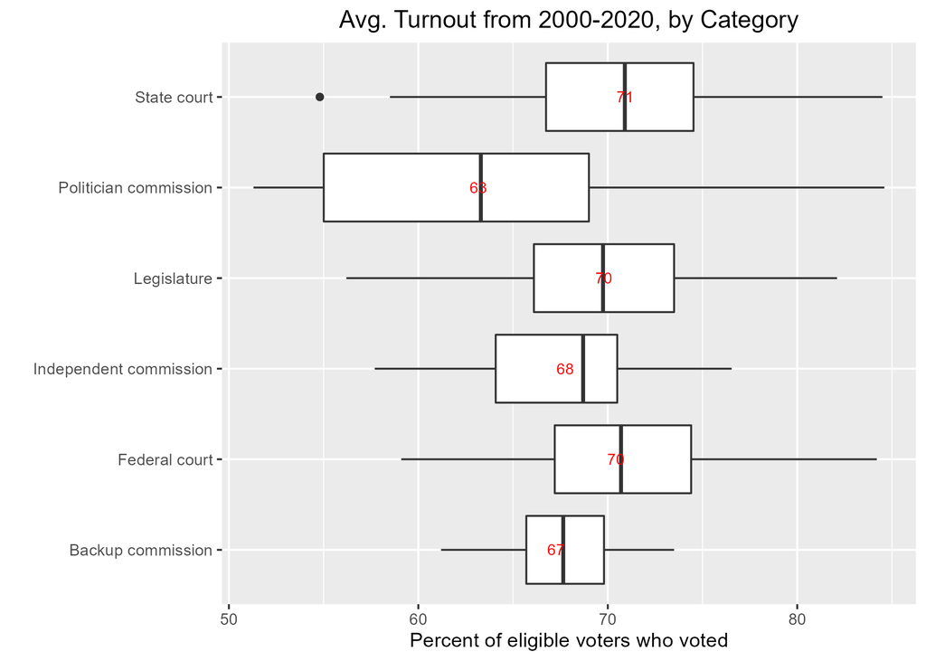

Fig. 2

# Descriptive: Trends through time

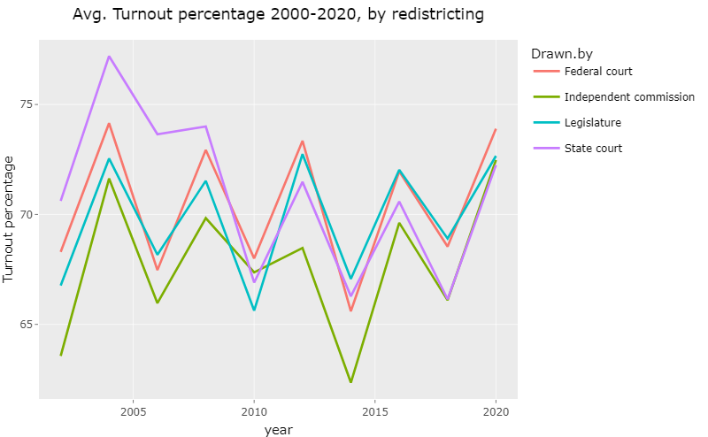

Fig. 3

- Visible decline in midterm elections.

# OLS Regression: Specification

- For each observation (state-election), policy is an unordered categorical variable.
- We run a model with all observations, and include a dummy variable for midterm years.

  $y_{i} = \beta_0 + \beta_1 Policy_{i} + \beta_2 Midterm_{i} + \epsilon_{i}$
- Then, run model separately for each sample (midterms vs presidential), without the midterm dummy.

# OLS Regression: Results

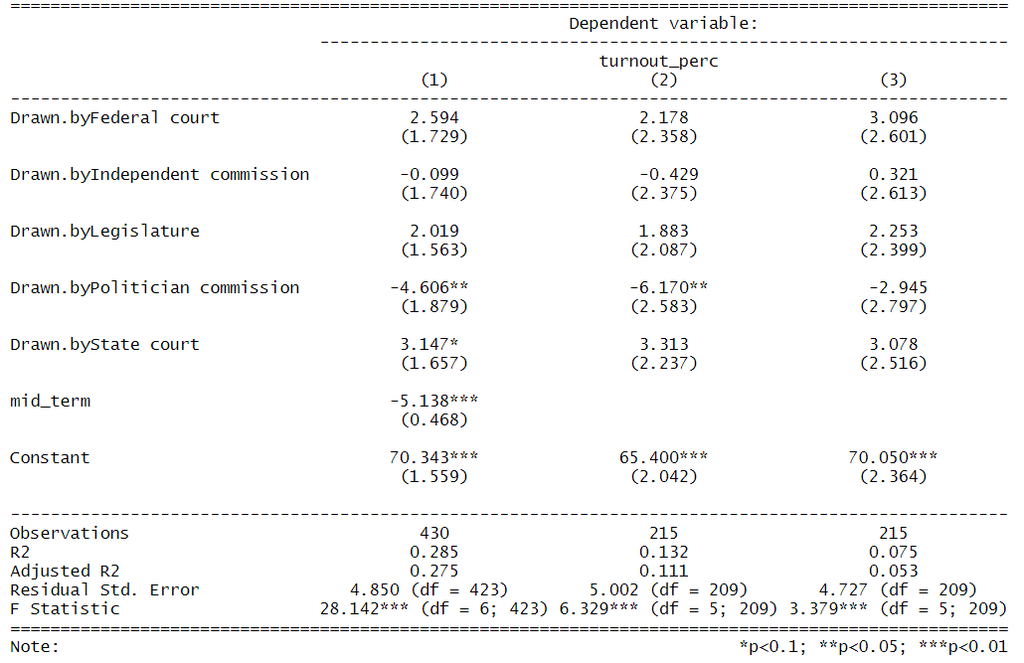

Table 1

- Politician commission has significant negative coefficient, while State Court has significant positive effects.

# OLS Regression: Results

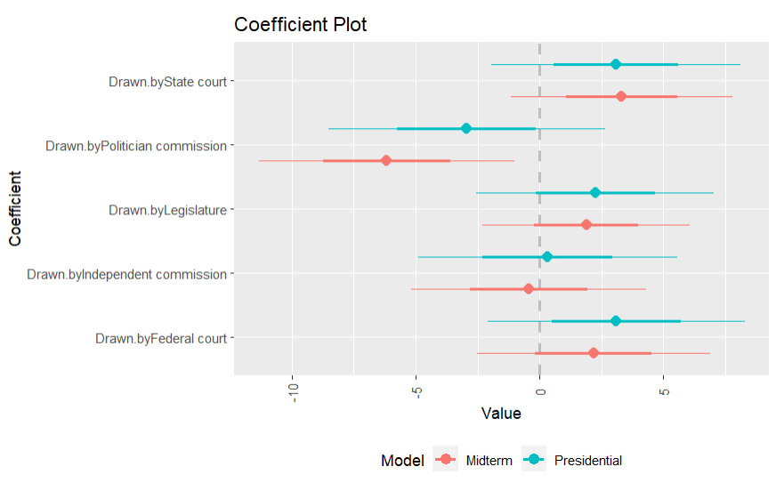

Fig. 4

- Politican commission associated with most negative coefficient. Effects more negative for midterms.

# Panel regression: fixed effects

- States and years have different characteristics that may affect the response variable (unobserved heterogeneity).
- Observations are correlated over time, error terms will be autocorrelated. Idiosyncratic effects with time.
- Panel model with fixed effects for the state and year variables.

  $y_{it} = \beta_{i} + \beta_1 Policy_{it} + \beta_2 year_t + \epsilon_{it}$
- Where  
  $y_{it} =$ Turnout percentage for state i in year t  
  $x_{it} =$ Binary variable for policy (court, legislature or partisan)  
  $\beta_{i} =$ Intercept/fixed effect for state i  
  $year_t =$ Intercept/fixed effect for year t  
  $\epsilon_{it} =$ Error term

# Panel regression: results

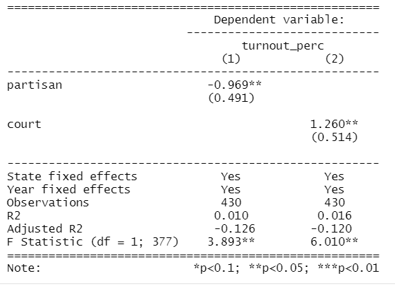

Table 2

- Partisan redistricting mechanisms associated with lower turnout, court with higher.
- Robust to state and year effects.
- Goodness of fit for fixed-effect models needs to be calculated separately. (Endsley 2016)

# Exploring vote margins

- The following plots Republican vs Democratic Votes for each district from 2000-2020, faceted by redistricting policy of the state.

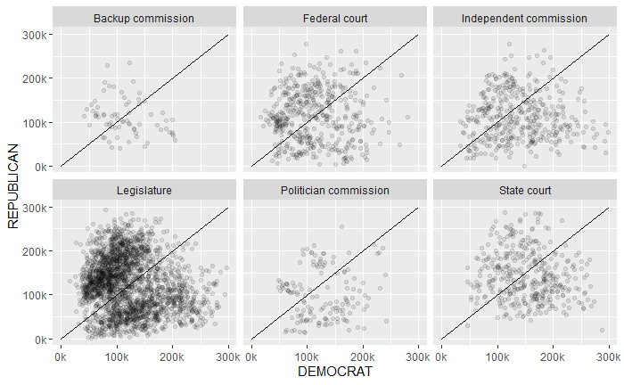

# Vote margins: Distribution

- We calculate the Democratic vote margin (in percent).
- Histogram for states with Legislature redistricting - bimodal distribution.

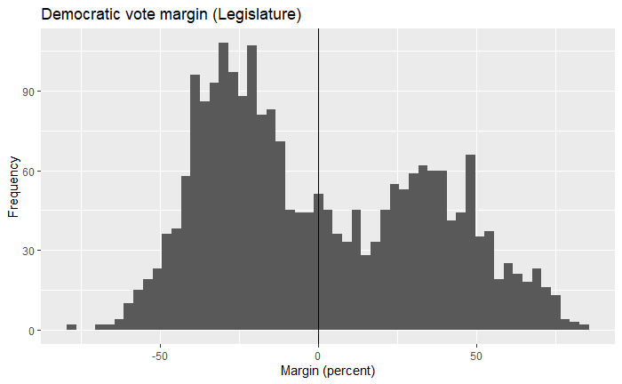

  Fig. 6

# Limitations and next steps

- Control variables, like demographics.
- District-level analysis.
- Stronger causal inference methods, like difference-in-differences.